# Assignment 6

Eli Chamberlain and Eric Zhou

2022-11-04

# Basic Setup

### Libraries

```r
library(lubridate)  # dates
library(caTools)  # random splitting
library(randomForest) # random forest prediction
library(caret)  # confusion matrix
library(cvms)  # used for plotting confusion matrices
library(tibble)
```

### [Austin Weather Data](https://www.kaggle.com/datasets/grubenm/austin-weather?select=austin_weather.csv)

```r
data <- read.csv('austin_weather.csv')
aw <- subset(data, select=-c(2, 4, 5, 7, 8, 10, 11, 13, 14, 16, 17, 19))
head(aw)
```

```
##         Date TempAvgF DewPointAvgF HumidityAvgPercent SeaLevelPressureAvgInches
## 1 2013-12-21       60           49                 75                     29.68
## 2 2013-12-22       48           36                 68                     30.13
## 3 2013-12-23       45           27                 52                     30.49
## 4 2013-12-24       46           28                 56                     30.45
## 5 2013-12-25       50           40                 71                     30.33
## 6 2013-12-26       48           36                 63                      30.4
##   VisibilityAvgMiles WindAvgMPH PrecipitationSumInches              Events
## 1                  7          4                   0.46 Rain , Thunderstorm
## 2                 10          6                      0
## 3                 10          3                      0
## 4                 10          4                      0
## 5                 10          2                      T
## 6                  9          3                      0
```

This is where we start our data analysis, weather data from Austin, Texas. We thought this would be interesting because recently Texas has had more extreme weather events than in the past, so we wanted to see if that had an effect on the overall climate of Texas. First, after looking at the data. We realized it was extremely repetitive and got rid of the highs and lows for each item and just kept the average values. We also looked at the size of our data, we were had 1319 days worth of data spanning from 2013 to July 2017. We found the date, average temperature, percipitation, and events to be the most interesting columns and that is what we decided to focus on.

# Dealing with Data

### Cleaning up columns and adding new ones

```r
# Doing date stuff
aw$Date<-as.POSIXct(aw$Date)
aw$Year<-year(aw$Date)
aw$Month<-month(aw$Date)
aw$Day<-day(aw$Date)

# Getting rid of bad values (a trace of rain with 0.001)
aw$PrecipitationSumInches[aw$PrecipitationSumInches == "T"] <- 0.001

# Splitting weather events
unique(aw$Events)  # Rain, fog, snow, thunderstorm
```

```
## [1] "Rain , Thunderstorm"       " "
## [3] "Rain"                      "Fog"
## [5] "Rain , Snow"               "Fog , Rain"
## [7] "Thunderstorm"              "Fog , Rain , Thunderstorm"
## [9] "Fog , Thunderstorm"
```

```r
aw$Rain <- grepl("Rain", aw$Events, fixed=TRUE)
aw$Fog <- grepl("Fog", aw$Events, fixed=TRUE)
aw$Snow <- grepl("Snow", aw$Events, fixed=TRUE)
aw$Storm <- grepl("Thunderstorm", aw$Events, fixed=TRUE)

# Getting rid of unnecessary columns
aw <- subset(aw, select=-c(9))
aw <- aw[,c(1, 9, 10, 11, 2, 3, 4, 6, 7, 5, 14, 13, 15, 8, 12)]
aw[,c(11:13, 15)] <-lapply(aw[,c(11:13, 15)], as.numeric)
aw[,c(11:13, 15)] <-lapply(aw[,c(11:13, 15)], factor)
```

Here we cleaned up our data so that we could use all of it as intended. This meant inputting .001 inches of precipitation for days that were given a value of “T”, which meant trace amounts of precipitation. This also meant converting different events to numerical data, 1s for TRUE and 0s for FALSE. Finally, this meant converting the dates into useable data points, we did this by extracting the month, day, and year of each date.

### Summary of data

```r
summary_aw <- aw
summary_aw[,c(2:10, 14)] <- lapply(aw[,c(2:10, 14)], as.numeric)
summary(summary_aw)
```

```
##       Date                             Year          Month
##  Min.   :2013-12-21 00:00:00.00   Min.   :2013   Min.   : 1.000
##  1st Qu.:2014-11-15 12:00:00.00   1st Qu.:2014   1st Qu.: 3.000
##  Median :2015-10-11 00:00:00.00   Median :2015   Median : 6.000
##  Mean   :2015-10-11 00:21:06.41   Mean   :2015   Mean   : 6.165
##  3rd Qu.:2016-09-04 12:00:00.00   3rd Qu.:2016   3rd Qu.: 9.000
##  Max.   :2017-07-31 00:00:00.00   Max.   :2017   Max.   :12.000
##
##       Day           TempAvgF      DewPointAvgF   HumidityAvgPercent
##  Min.   : 1.00   Min.   :29.00   Min.   : 8.00   Min.   :27.00
##  1st Qu.: 8.00   1st Qu.:62.00   1st Qu.:46.00   1st Qu.:59.00
##  Median :16.00   Median :73.00   Median :61.00   Median :67.00
##  Mean   :15.81   Mean   :70.64   Mean   :56.63   Mean   :66.67
##  3rd Qu.:23.00   3rd Qu.:83.00   3rd Qu.:69.00   3rd Qu.:74.00
##  Max.   :31.00   Max.   :93.00   Max.   :76.00   Max.   :97.00
##                                  NA's   :7       NA's   :2
##  VisibilityAvgMiles   WindAvgMPH     SeaLevelPressureAvgInches Snow
##  Min.   : 2.000     Min.   : 1.000   Min.   :29.55             0:1318
##  1st Qu.: 9.000     1st Qu.: 3.000   1st Qu.:29.91             1:   1
##  Median :10.000     Median : 5.000   Median :30.00
##  Mean   : 9.162     Mean   : 5.008   Mean   :30.02
##  3rd Qu.:10.000     3rd Qu.: 6.000   3rd Qu.:30.10
##  Max.   :10.000     Max.   :12.000   Max.   :30.74
##  NA's   :12         NA's   :2        NA's   :3
##  Fog      Storm    PrecipitationSumInches Rain
##  0:1250   0:1131   Min.   :0.0000         0:942
##  1:  69   1: 188   1st Qu.:0.0000         1:377
##                    Median :0.0000
##                    Mean   :0.1145
##                    3rd Qu.:0.0010
##                    Max.   :5.2000
##
```

We took our remaining data points and gave the summary of each of them. This gave us a very easy way to look at and access all of our data highs and lows quickly.

### Peek into weather data

```r
length(aw$Rain)
```

```
## [1] 1319
```

```r
sum(aw$Rain == 1)
```

```
## [1] 377
```

```r
sum(aw$Fog == 1)
```

```
## [1] 69
```

```r
sum(aw$Snow == 1)
```

```
## [1] 1
```

```r
sum(aw$Storm == 1)
```

```
## [1] 188
```

# Graphs for Patterns

### Austin Temperatures w/ Time

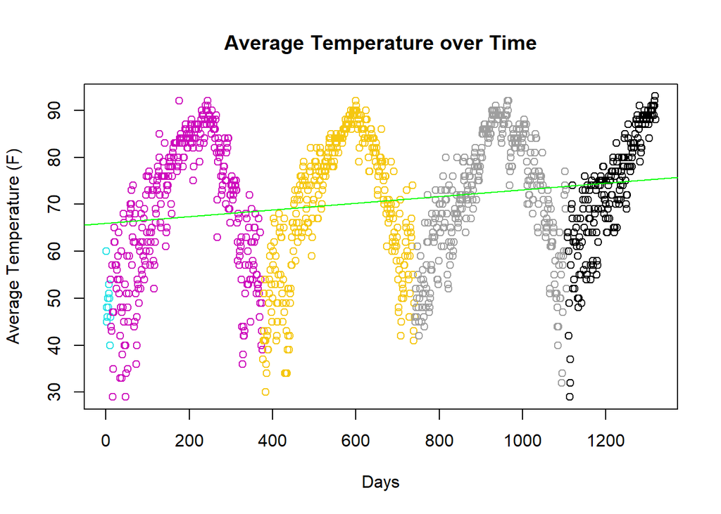

```r
plot(aw$TempAvgF, col=aw$Year, main="Average Temperature over Time", ylab="Average Temperature (F)", xlab="Days")
abline(lm(aw$TempAvgF~seq(length(aw$TempAvgF))), col="green")
```

First we made many graphs between various factors throughout the data. We removed the code for the sake of cleanliness and not to clutter the file too much. We then looked more into relationships we found interesting and created the better graphs you are seeing now.

This is the first graph that we thought would be very interesting: Time versus temperature. We started with a plain graph of time overall (every part of the year). We then separated each year by color and saw 2 very interesting things. The first was that there was a general trend of increasing temperatures, so with that we plotted a trend line to confirm our suspicion. It did, over time the temperature was increasing. The second thing we noticed was that in the beginning of the year (Janurary), the temperatures were much more spread out than during the middle of the year (July). We thought it would be interesting to take both of those months and plot them separately.

### January Temperatures w/ Time

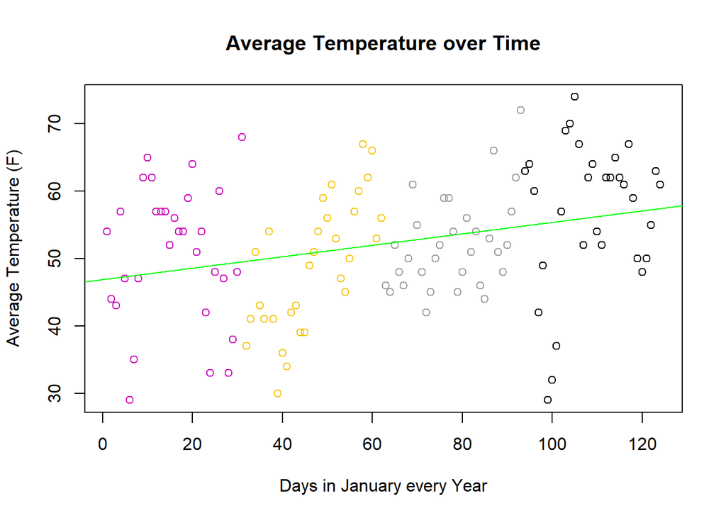

```r
plot(aw$TempAvgF[aw$Month==1], col=aw$Year[aw$Month==1],main="Average Temperature over Time", ylab="Average Temperature (F)", xlab="Days in January every Year")
abline(lm(aw$TempAvgF[aw$Month==1]~seq(length(aw$TempAvgF[aw$Month==1]))), col="green")
```

### July Temperatures w/ Time

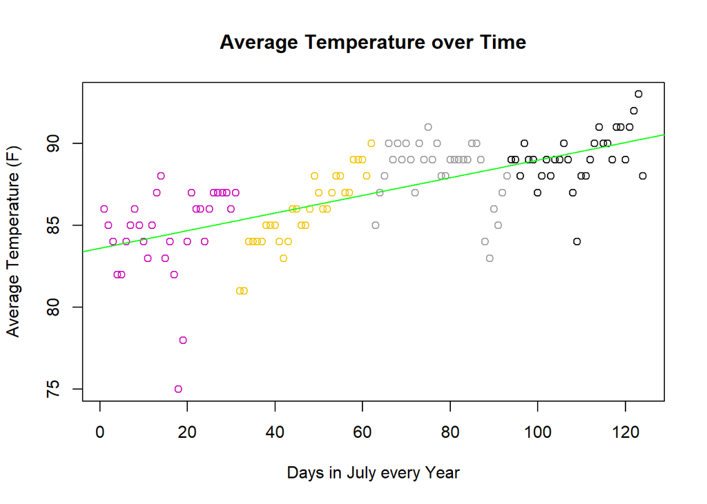

```r
plot(aw$TempAvgF[aw$Month==7], col=aw$Year[aw$Month==7],main="Average Temperature over Time", ylab="Average Temperature (F)", xlab="Days in July every Year")
abline(lm(aw$TempAvgF[aw$Month==7]~seq(length(aw$TempAvgF[aw$Month==7]))), col="green")
```

### January Temperature Distribution

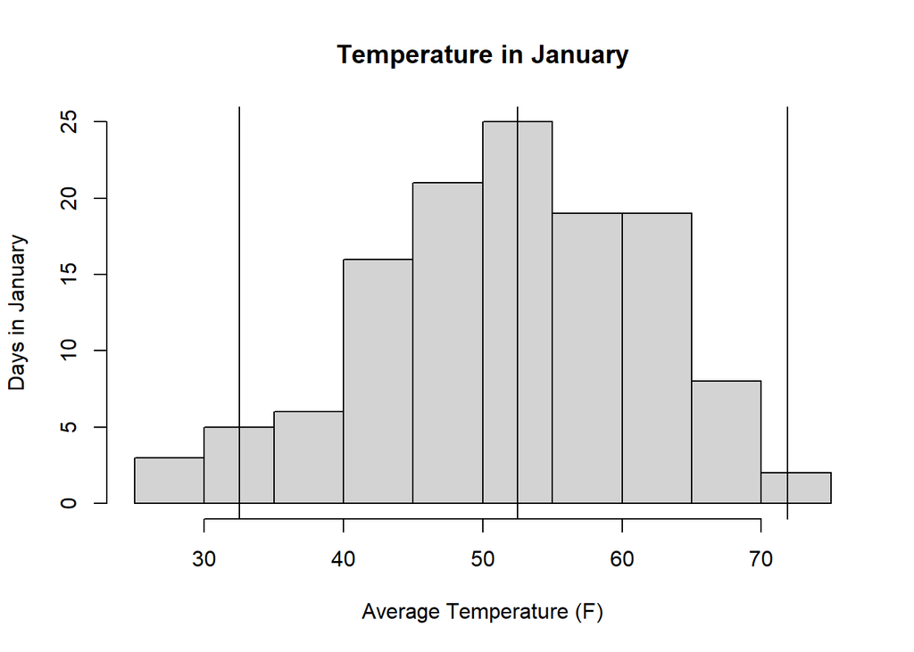

```r
hist(aw$TempAvgF[aw$Month==1], main="Temperature in January", xlab="Average Temperature (F)", ylab="Days in January")
abline(v=median(aw$TempAvgF[aw$Month==1]))
abline(v=mean(aw$TempAvgF[aw$Month==1] + 2 * sd(aw$TempAvgF[aw$Month==1])))
abline(v=mean(aw$TempAvgF[aw$Month==1] - 2 * sd(aw$TempAvgF[aw$Month==1])))
```

We wanted to know more about the variation of our data, so we decided to put it into a histogram. This proved our thoughts that there was a great deal of variance in January. The outer lines of the histogram represent 95% of our data and were found by adding or subtracting 2 times the standard deviation of the data. this means that 95% of the temperatures in January fall between 32 and 72 degrees. That is a very large range, and by taking the 95% it generally weeds out the outliers, so this proves generally high variance in temperatures in January.

### July Temperature Distribution

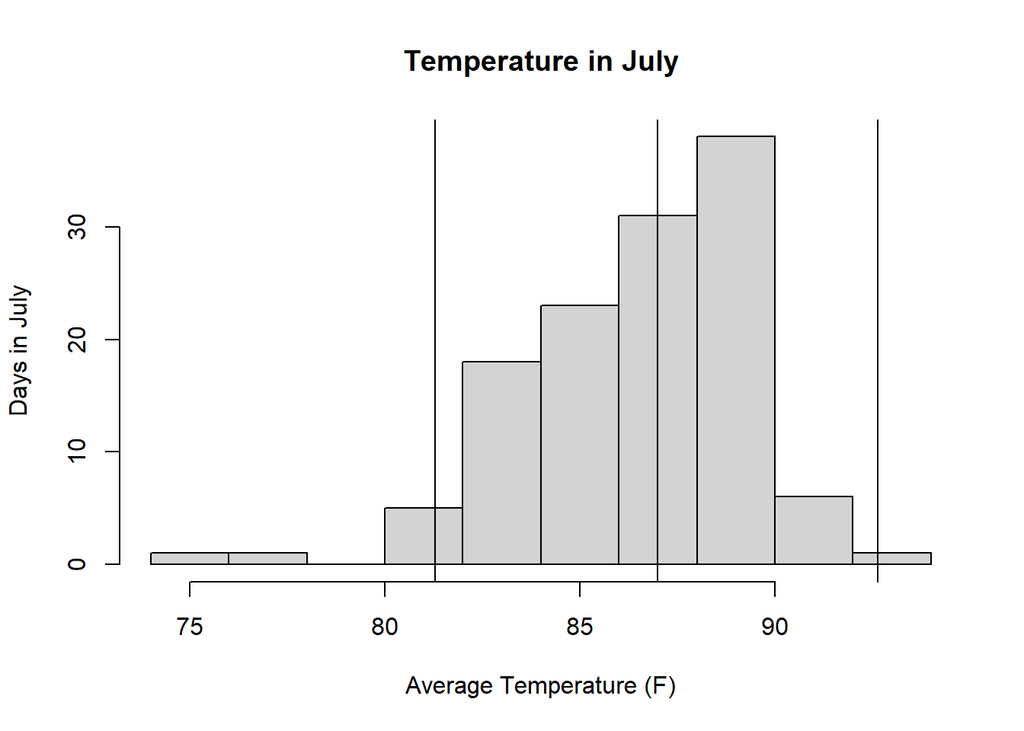

```r
hist(aw$TempAvgF[aw$Month==7],main="Temperature in July", xlab="Average Temperature (F)", ylab="Days in July")
abline(v=median(aw$TempAvgF[aw$Month==7]))
abline(v=mean(aw$TempAvgF[aw$Month==7] + 2 * sd(aw$TempAvgF[aw$Month==7])))
abline(v=mean(aw$TempAvgF[aw$Month==7] - 2 * sd(aw$TempAvgF[aw$Month==7])))
```

### January Temperature Boxplots

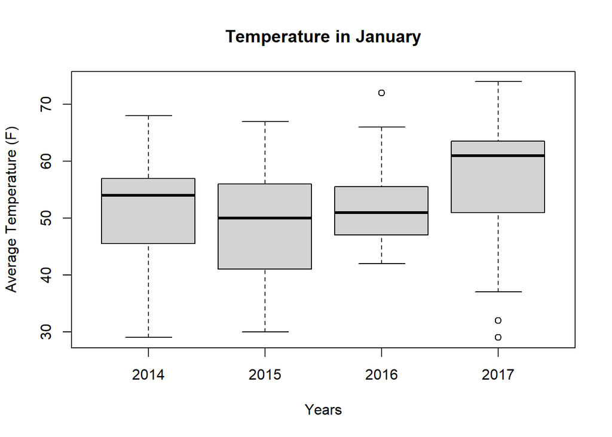

```r
boxplot(aw$TempAvgF[aw$Month==1]~aw$Year[aw$Month==1],main="Temperature in January", ylab="Average Temperature (F)", xlab="Years")
```

To make sure that there was not any one year that throws off all of our data, as the histogram takes the temperatures from all the years and combines it into one, we made boxplots to represent each year. These boxplots showed that there was not one year that truly threw off the data. In 2016, there was less varience in the data, but it is not extreme enough to make a large difference in the data. also, the median for 2017 is higher than the rest, but again, it is not extreme enough to make a big difference. There are also only 3 outliers of the 124 total days in January so that means our data is pretty consistent.

### July Temperature Boxplots

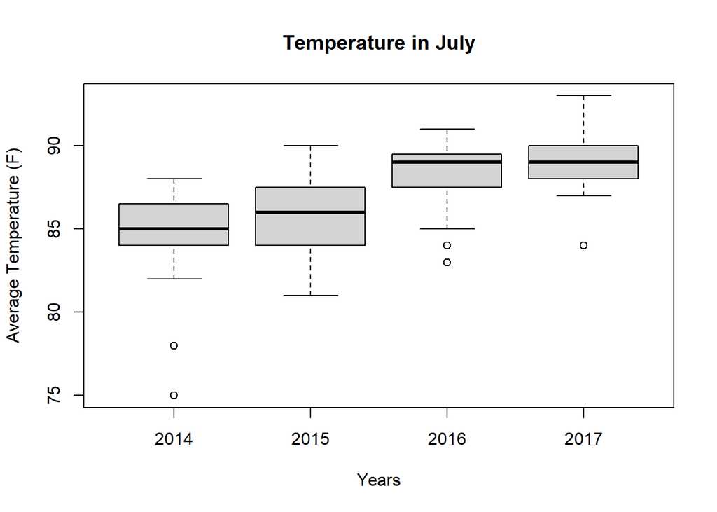

```r
boxplot(aw$TempAvgF[aw$Month==7]~aw$Year[aw$Month==7],main="Temperature in July", ylab="Average Temperature (F)", xlab="Years")
```

We did the exact same thing for July as we did January. This again proved that the variance is a lot lower than that of January as both the whiskers and the box part of the plot are significantly smaller and represent a much smaller range. This set of plots however also shows consistent increase of temperature over the course of the four years as the highest end of the box increases each year.

# Rain Prediction Model

### Splitting data

```r
set.seed(49301)
ind <- sample.split(Y=aw, SplitRatio=0.8)
trainData <- aw[ind,]
testData <- aw[!ind,]
length(trainData$Date)
```

```
## [1] 1055
```

```r
length(testData$Date)
```

```
## [1] 264
```

Here, to properly test the model, I split the data into a training set with 80% of the data and a testing set with 20% of the data. I used the length part to check to make sure the proportions are about right.

### Creating random forest

```r
start <- Sys.time()
forest <- randomForest(formula=Rain~.-PrecipitationSumInches, data=trainData)  # dropping precipitation for prediction
end <- Sys.time()
(time <- end - start)  # total time for forest
```

```
## Time difference of 1.636036 secs
```

```r
forest  # forest information
```

```
##
## Call:
##  randomForest(formula = Rain ~ . - PrecipitationSumInches, data = trainData)
##                Type of random forest: classification
##                      Number of trees: 500
## No. of variables tried at each split: 3
##
##         OOB estimate of  error rate: 12.99%
## Confusion matrix:
##     0   1 class.error
## 0 703  47  0.06266667
## 1  90 215  0.29508197
```

I trained the default random forest on the training set after removing the precipitation (since that is clearly indicative of rain), the model seems to do pretty well on training data.

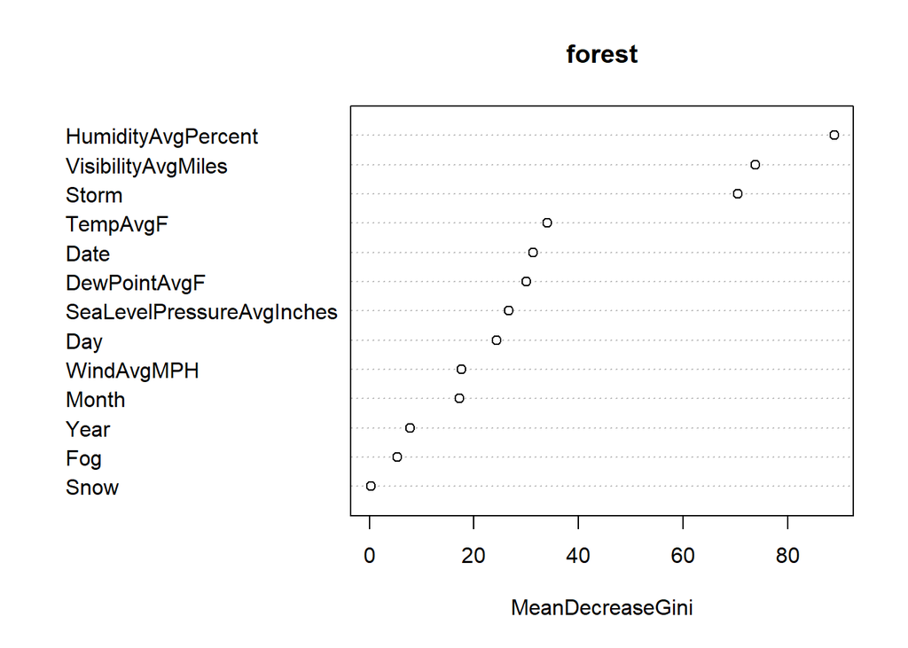

```r
varImpPlot(forest)  # plot of importance of each variable
```

This is a plot that shows the importance of each variable in the forest, specifically how much each variable decreases the error.

### Looking at relationships

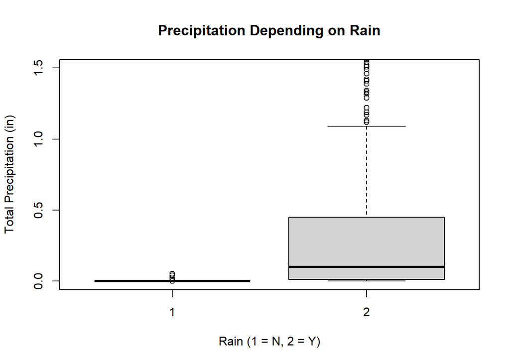

```r
boxplot(as.numeric(aw$PrecipitationSumInches) ~ as.numeric(aw$Rain), xlab="Rain (1 = N, 2 = Y)", ylab="Total Precipitation (in)", main="Precipitation Depending on Rain", ylim=c(0, 1.5))
```

We can see that there’s not much precipitation in Austin but also that without rain, the total inches is just 0 (excluding outliers). This factor is too obvious so I decided to remove it from our model.

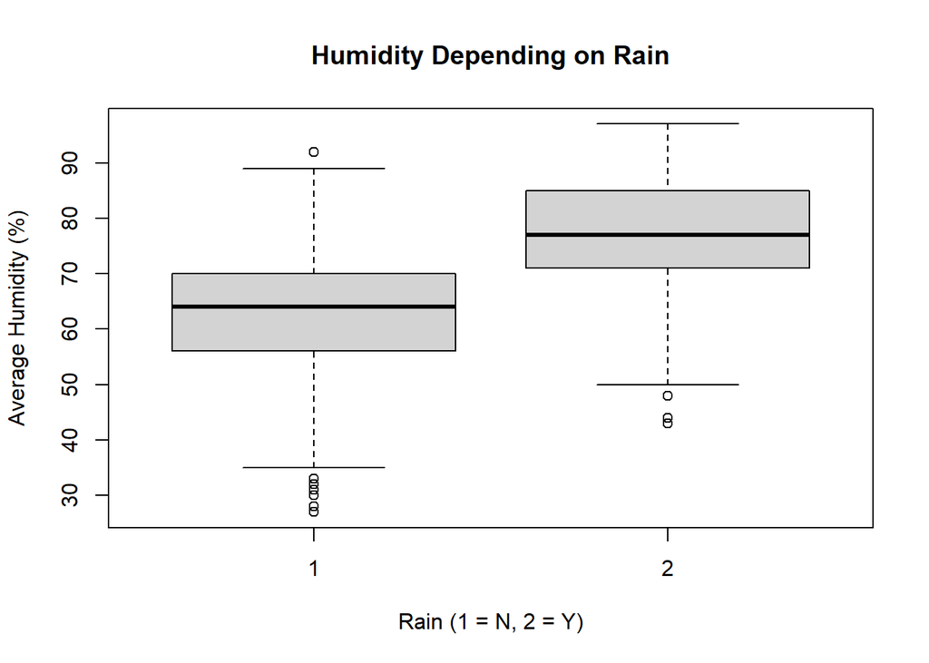

```r
boxplot(as.numeric(aw$HumidityAvgPercent) ~ as.numeric(aw$Rain), xlab="Rain (1 = N, 2 = Y)", ylab="Average Humidity (%)", main="Humidity Depending on Rain")
```

With humidity, we can see the difference but also that there is overlap.

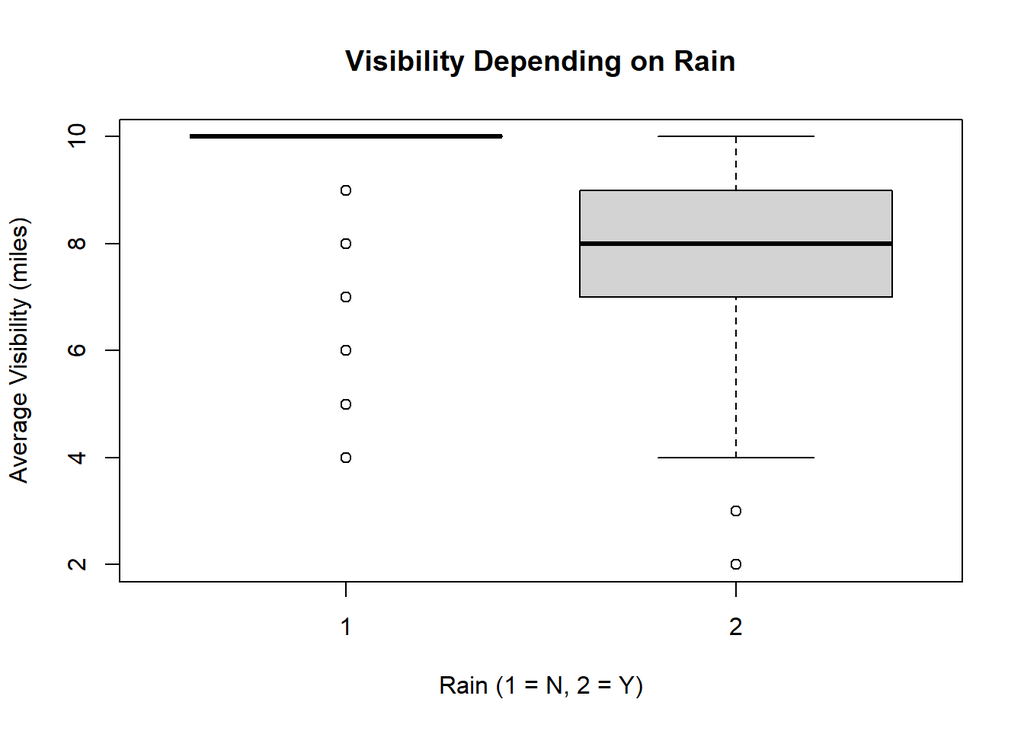

```r
boxplot(as.numeric(aw$VisibilityAvgMiles) ~ as.numeric(aw$Rain), xlab="Rain (1 = N, 2 = Y)", ylab="Average Visibility (miles)", main="Visibility Depending on Rain")
```

Visibility seems to be a good indicator for rain as well with a concentration at 10 without rain and lower with rain.

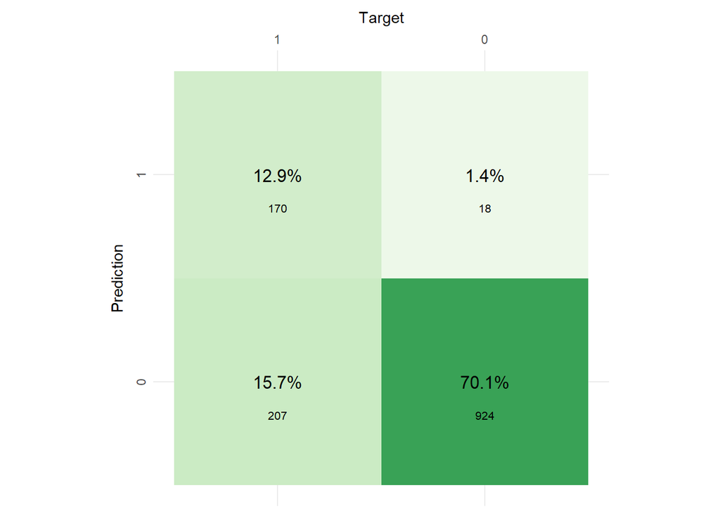

```r
plot_confusion_matrix(as_tibble(table(tibble('trgt' = aw$Rain, 'pred' = aw$Storm))),
                      target_col = 'trgt',
                      prediction_col = 'pred',
                      counts_col = 'n',
                      palette = 'Greens',
                      add_counts = T,
                      add_zero_shading = F,
                      add_col_percentages = F,
                      add_row_percentages = F,
                      rm_zero_text = F)
```

Here, I used storm as the sole predictor for rain. The overall accuracy was 83% which is really good and shows the strong relationship between the two.

### Testing default forest

```r
set.seed(49301)
p <- predict(forest, testData, type="class")
cm <- confusionMatrix(as.factor(p), as.factor(testData$Rain))
cm$overall[1]
```

```
## Accuracy
## 0.844697
```

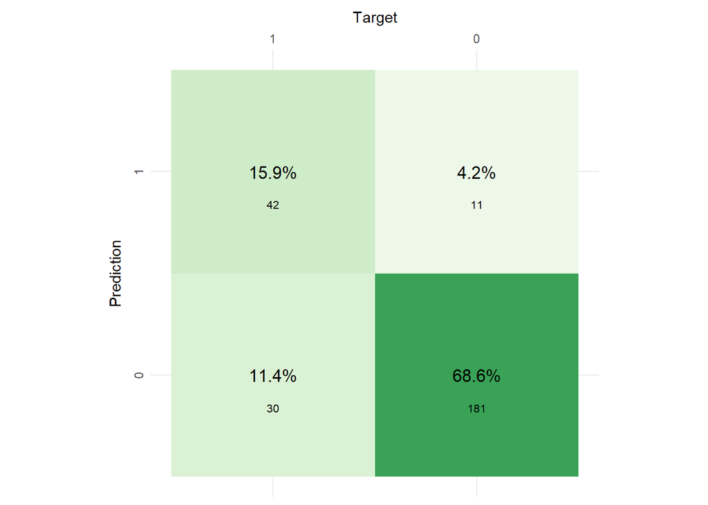

```r
plot_confusion_matrix(as_tibble(table(tibble('trgt' = testData$Rain, 'pred' = p))),
                      target_col = 'trgt',
                      prediction_col = 'pred',
                      counts_col = 'n',
                      palette = 'Greens',
                      add_counts = T,
                      add_zero_shading = F,
                      add_col_percentages = F,
                      add_row_percentages = F,
                      rm_zero_text = F)
```

Here, I tested the random forest I created on the testing set and got ~84.47% accuracy. Most of the dataset is skewed towards no rain there’s a lot of true negatives.

### Tuning mtry

```r
set.seed(49301)
start <- Sys.time()
tuned_model <- tuneRF(
  x=trainData[,-14:-15],
  y=trainData$Rain,
  ntreeTry=500,
  mtryStart = 3,
  stepFactor = 1.5,
  improve = 0.01,
  trace = FALSE
)
```

```
## 0.007246377 0.01
## -0.02173913 0.01
```

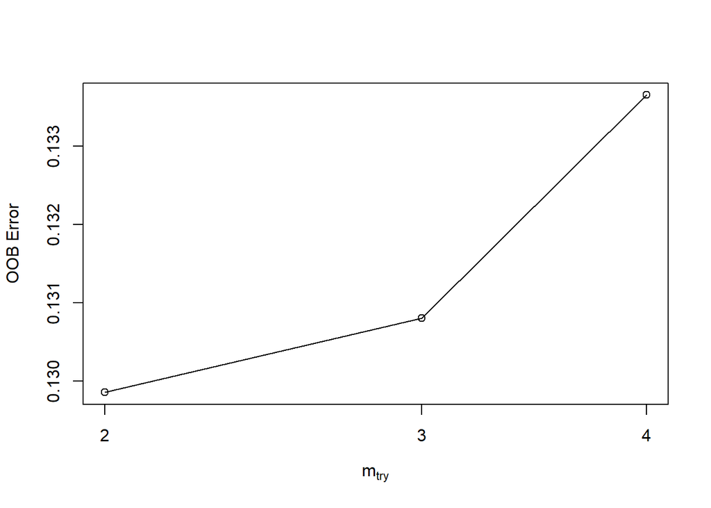

```r
end <- Sys.time()
(time <- end - start) # time for tuning
```

```
## Time difference of 2.363884 secs
```

I try to improve my model by tuning mtry, the number of different variables it looks at for partitioning for each decision tree.

### Creating tuned forest

```r
set.seed(49301)
tuned_forest <- randomForest(formula=Rain~.-PrecipitationSumInches, data=trainData, ntree=500, mtry=2)
```

### Testing tuned forest and showing results

```r
testData['Predictions'] <- predict(tuned_forest, testData)
testData[11:35,-14]
```

```
##           Date Year Month Day TempAvgF DewPointAvgF HumidityAvgPercent
## 55  2014-02-13 2014     2  13       51           34                 58
## 58  2014-02-16 2014     2  16       68           57                 74
## 62  2014-02-20 2014     2  20       70           50                 48
## 70  2014-02-28 2014     2  28       62           46                 60
## 73  2014-03-03 2014     3   3       36           20                 56
## 77  2014-03-07 2014     3   7       53           42                 65
## 85  2014-03-15 2014     3  15       68           62                 81
## 88  2014-03-18 2014     3  18       65           42                 49
## 92  2014-03-22 2014     3  22       69           62                 80
## 100 2014-03-30 2014     3  30       62           43                 56
## 103 2014-04-02 2014     4   2       76           67                 78
## 107 2014-04-06 2014     4   6       57           49                 76
## 115 2014-04-14 2014     4  14       58           46                 65
## 118 2014-04-17 2014     4  17       62           57                 85
```

[output cut: 63 more lines]

```r
testData[11:35,15:16]
```

```
##     Rain Predictions
## 55     0           0
## 58     0           0
## 62     0           0
## 70     0           0
## 73     1           1
## 77     0           0
## 85     1           0
## 88     0           0
## 92     0           1
## 100    0           0
## 103    1           0
## 107    1           1
## 115    1           1
## 118    1           1
## 122    1           1
## 130    0           0
## 133    0           0
## 137    0           0
## 145    1           0
## 148    0           0
## 152    0           0
## 160    0           0
## 163    0           0
## 167    0           0
## 175    0           0
```

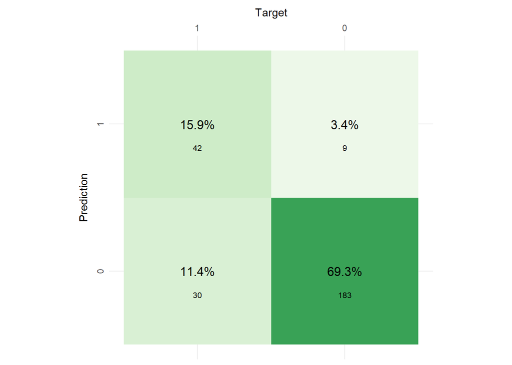

```r
# testData[90:100,]
cm <- confusionMatrix(as.factor(testData$Predictions), as.factor(testData$Rain))
# cm$overall[1]
plot_confusion_matrix(as_tibble(table(tibble('trgt' = testData$Rain, 'pred' = testData$Predictions))),
                      target_col = 'trgt',
                      prediction_col = 'pred',
                      counts_col = 'n',
                      palette = 'Greens',
                      add_counts = T,
                      add_zero_shading = F,
                      add_col_percentages = F,
                      add_row_percentages = F,
                      rm_zero_text = F)
```

The final accuracy of the tuned model on the testing set was 85.23%.